# Two Stage Least Squares and IV Inference

73-374 Econometrics II

## Today

- Multivariate IV: Two Stage Least Squares
- Testing IV Assumptions

## Multiple Instruments

- Is there a multivariate version of IV like there is for regression?
- Yes, but now 2 types of multiple variables
  - Multiple instruments $Z$
  - Multiple endogenous regressors
- To start: multiple instruments
- Allows us to weaken random assignment of instrument to *conditional random assignment*
  - Any case where control strategy will let us estimate causal effect of instrument, can do modified IV
- Deal with constant effects linear model case only

## IV model with multiple instruments

- Let $Z$ be an $m+1\times 1$ vector of instruments
- Include constant term $Z_0=1$
- Regressor of interest, call it $Y_2$, still endogenous scalar (correlated with residual)
- Allow first $k+1<m+1$ instruments to affect $Y_1$ directly
  - These act as control variables
- Still need at least one *excluded* instrument with no direct effect
- Model becomes
  $$Y_{1i}=\beta_0+\beta_1Y_{2i} + \beta_2Z_{1i} + \beta_3Z_{2i} + ... + \beta_{k+1}Z_{ki} + u_{i}$$
- Endogeneity means
  $$E[Y_2u]\neq 0$$
- For convenience call $X=(1,Y_2,Z_1,\ldots,Z_k)^\prime$
  $$Y_{1i}=X_i^{\prime}\beta+u_i$$

## Interpretation: Causal Graph (code)

```r
#Library to create and analyze causal graphs
library(dagitty)
library(ggdag) #library to plot causal graphs
#create graph
iv2graph<-dagify(Y1~Y2+Z1+W,Y2~Z1+Z2+W,Z2~Z1)
#Set position of nodes
  coords<-list(x=c(Y2 = 0, W = 1, Y1 = 2, Z1=-1, Z2=-1),
          y=c(Y2 = 0, W = 0.1, Y1 = 0, Z1=0.1,Z2=0))
  coords_df<-coords2df(coords)
  coordinates(iv2graph)<-coords2list(coords_df)
  #Plot causal graph
ggdag(iv2graph)+theme_dag_blank()+labs(title="Multivariate IV")
```

## Interpretation: Causal Graph

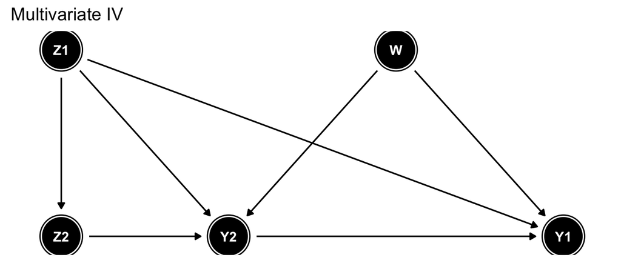

- Want effect of **endogenous regressor** $Y2$ on outcome $Y1$
  - Unobserved confounder $W$ prevents using regression
  - Even when adjusting for observed confounders $Z1$
- **Excluded instruments** $Z2$ directly affect $Y2$ but *not* $Y1$
- By adjusting for **included instruments** $Z1$, effect of excluded instrument $Z2$ on $Y2$ can be estimated
- Effect of $Z2$ on $Y1$ can also be estimated by controlling for $Z1$
- Like univariate IV, but now *conditional* random assignment
- Can have multiple included instruments $Z1$ or excluded instruments $Z2$

## IV assumptions

- Exclusion restriction is now
  - $E[Z_ju]= 0$ for all instruments $j=0\ldots m$
- Let’s look at special case where there is exactly one instrument not included in the stuctural equation, $m=k+1$
- Model and exogeneity give us system of k+2 equations in k+2 unknowns
  $$E[Z_{ji}(Y_{1i}-\beta_0-\beta_1Y_{2i}-\beta_2Z_{1i} - ... - \beta_{k+1}Z_{ki})]=0\ \forall j=0\ldots m$$
- Estimate by sample means in place of expectations
- Multivariate IV estimator
- Exactly standard IV in case where k=0 (no controls)
- Relevance condition now says that this system has a unique solution
  - Requires $Z$ to be related to $Y_2$

## Many excluded instruments

- If $m>k+1$, exclusion restictions give more equations than unknowns
- Model said to be **overidentified**
- Can drop any subset of Zs to just use $k+2$ of them
  - So long as relevance still holds
- Or use any $k+2$ *linear combinations* of $Z$
- Let $\tilde{Z}$ be vector of $k+2$ linear combinations of elements of $Z$
  - Use subsets or weighted averages of instruments
- Then
  $$E[\tilde{Z}_i(Y_{1i}-X_i^{\prime}\beta)]=0$$
  holds
- Solving for $\beta$ and replacing mean with sample average gives $\hat{\beta}^{IV}$

## Example: Incarceration and crime

- Suppose we have $m+1$ judges, and an indicator for each
- $Y_1$ is recidivism, $Y_2$ is sentence length
- With no controls, multivariate IV is just univariate IV with a particular pair of judges as IV
- Can use linear combinations to get more precise estimates: compare average of judges who give lots of time to average of those who give little
- With controls, get effect of incarceration on crime conditioning on (exogenous) characteristics
- Adding controls can also help ensure instrument uncorrelated with residual
  - Include any omitted variable which is correlated with instrument and affects outcome
  - E.g., if judges assigned randomly conditional on district, and district correlated with crime, include district as an included instrument

## Finding the “right” linear combination

- Intuitively, by combining the multiple valid IV estimators, should get better estimate (at least if model right)
- Do this by choosing “right” linear combination of instruments
- Under some assumptions, there is a choice which gives smallest variance
- Called **Two Stage Least Squares**
- First, Regress $Y_2$ on $Z$ to get predicted value $\hat{Y}_2=\phi_0 +\phi_1Z_1+\phi_2 Z_2+...\phi_mZ_m$
- Use this and $Z_0\ldots Z_k$ as k+2 elements of $\tilde{Z}$

## Implementing 2SLS

- Equivalent to regressing $Y_2$ on $Z$ to get predicted value $\hat{Y}_2=\phi_0 +\phi_1Z_1+\phi_2 Z_2+...\phi_mZ_m$
- Then replacing $Y_2$ with $\hat{Y}_2$ in structural function and running regression
  $$Y_{1i}=\beta_0+\beta_1\hat{Y}_{2i} + \beta_2Z_{1i} + \beta_3Z_{2i} + ... + \beta_{k+1}Z_{ki} + u_{i}$$
- Denote matrix of regressors here $\hat{X}_i$
- Coefficient on $\hat{Y}_{2i}$ is $\hat{\beta}_1^{2SLS}$
- Need at least one excluded instrument with non-zero first stage coefficient for $\hat{Y}_{2i}$ to not be a linear combination of other regressors
  - This is relevance or no multicollinearity condition
- Caveat: Don’t do this in R by running OLS twice!
  - Why? Standard errors will be wrong
  - Don’t take into account first stage uncertainty
  - Use $ivreg$ command in package $AER$

## 2SLS assumptions

- (2SLS1) Linear Model
  $$Y_{1i}=\beta_0+\beta_1Y_{2i} + \beta_2Z_{1i} + \beta_3Z_{2i} + ... + \beta_{k+1}Z_{ki} + u_{i}$$
- (2SLS2) Random sampling: $(Y_{1i},Y_{2i},Z_i)$ drawn i.i.d. from population satisfying linear model assumptions
- (2SLS3) Relevance
  - Need at least as many instruments correlated with $X$ as parameters
- (2SLS4) Exogeneity
  $$E[Z_{ij}u_i]=0\ \forall j=1\ldots m+1$$
- To perform inference, sometimes assume (2SLS5) Homoskedasticity
  $$E[u^2|Z]=\sigma^2$$
  ($\sigma^2$ a finite nonzero constant)

## Results

- Under (1-4), 2SLS consistent
- Relevance condition more complicated
- Necessary conditions:
  - At least one instrument is not included as a control: $m+1>k$
  - First stage regression of $Y_2$ on $Z$ has nonzero coefficient on an excluded regressor
  - Otherwise it is a linear combination of included $Z$, and so there is multicollinearity
- Under (1-4), asymptotically normal inference is possible
- Under (1-5), 2SLS is also choice of linear combination of instruments with smallest asymptotic variance
- As usual, can use Robust SEs if (5) fails

## Example: Cigarette Demand with controls (Code)

```r
#Load library containing IV command 'ivreg'
library(AER)
# Load data on cigarette prices and quantities
data("CigarettesSW")
#Use real prices as X
CigarettesSW$rprice <- with(CigarettesSW,
                            price/cpi)
#Use changes in cigarette tax
# as supply curve shifting instrument
CigarettesSW$tdiff <- with(CigarettesSW,
                           (taxs - tax)/cpi)
#data from different states in 1995
c1995 <- subset(CigarettesSW,
                year == "1995")
```

## Example: Cigarette Demand with controls

- Predict cigarette demand controlling for income
  - Income may affect sales, but also state tax policy
- Use same data as last class
- $Y_1$ log Quantity Demanded
- $Y_2$ log Price
- $Z_1$ (included) income level
- $Z_2$ (excluded) state cigarette tax rates
  $$Y_1=\beta_0+\beta_1Y_2+\beta_2Z_1 + u$$
- To run 2SLS, use $ivreg$ in $AER$ library, with syntax
- **ivreg(y1 ~ y2 + z1 + … + zk | z1 + … + zm)**

## Results (Code 1)

```r
#To get IV estimate of effect of x on y using
#  z as instrument syntax is
# ivreg(y1 ~ y2 + z1 + ... + zk | z1 + ... + zm)
# Effect of log(price) on log(quantity)
# controlling for income
# Elasticity
fm_ivreg <- ivreg(log(packs) ~ log(rprice) + income
                  | tdiff + income, data = c1995)
#Obtain (robust) standard errors
ivresults<-coeftest(fm_ivreg,
         vcov = vcovHC(fm_ivreg, type = "HC0"))
```

## Results (Code 2)

```r
#Compare to simple IV (no controls),
#first stage, and reduced form
fm_ols<-lm(log(packs) ~ log(rprice) + income,
           data=c1995)
fm_simpleIV<-ivreg(log(packs) ~ log(rprice)
                  | tdiff, data = c1995)
fm_firststage<-lm(log(rprice)~tdiff + income,
                  data = c1995)
fm_reducedform<-lm(log(packs)~tdiff + income,
                   data = c1995)
```

## Results (Code 3)

```r
#Obtain robust standard errors for each
fm_ols.coef<-coeftest(fm_ols,
    vcov = vcovHC(fm_ols, type = "HC0"))
fm_simpleIV.coef<-coeftest(fm_simpleIV,
    vcov = vcovHC(fm_simpleIV, type = "HC0"))
fm_firststage.coef<-coeftest(fm_firststage,
    vcov = vcovHC(fm_firststage, type = "HC0"))
fm_reducedform.coef<-coeftest(fm_reducedform,
    vcov = vcovHC(fm_reducedform, type = "HC0"))
```

## Results (Code 4)

```r
library(stargazer)
stargazer(fm_simpleIV.coef,ivresults,fm_ols.coef,
    type="html",header=FALSE,no.space=TRUE,
    title="2SLS, OLS, Simple IV",
    column.labels=c("Simple IV"), # "2SLS","OLS",
    omit.table.layout="nl")
```

## Results

**2SLS, OLS, Simple IV**

[output not shown]

## 2SLS vs First Stage and Reduced Form (Code)

```r
stargazer(ivresults,fm_firststage.coef,fm_reducedform.coef,
    type="html",header=FALSE,no.space=TRUE,
    title="2SLS, First Stage, and Reduced Form",
    column.labels=c("log(packs)",
                    "log(rprice)",
                    "log(packs)"),
    omit.table.layout="n")
```

## 2SLS vs First Stage and Reduced Form

**2SLS, First Stage, and Reduced Form**

|  | *Dependent variable:* |  |  |
| --- | --- | --- | --- |
|  | log(packs) | log(rprice) | log(packs) |
|  | (1) | (2) | (3) |
| log(rprice) | -0.919*** |  |  |
|  | (0.312) |  |  |
| tdiff |  | 0.029*** | -0.026*** |
|  |  | (0.005) | (0.010) |
| income | -0.000* | 0.000 | -0.000*** |
|  | (0.000) | (0.000) | (0.000) |
| Constant | 8.974*** | 4.610*** | 4.738*** |
|  | (1.487) | (0.028) | (0.063) |

## Multiple endogenous variables

- Linear model with endogeneity
  $$Y_{1i}=\beta_0+\beta_1Y_{2i} + \beta_2Y_{3i} + \ldots + \beta_{\ell}Y_{\ell i} + \beta_{\ell+1}Z_{1i} + ... + \beta_{k+\ell}Z_{ki} + u_{i}$$
- $Y_{-1}=(Y_2\ldots Y_\ell)$ are **endogenous** regressors

$$E[Y_{-1i}u_i]\neq 0$$

- More compact notation
  - $X_i=(1,Y_{2i},\ldots,Y_{\ell i},Z_{1i},\ldots,Z_{ki})^{\prime}$
  - $Y_{1i}=X_i^{\prime}\beta + u_{i}$
- Instruments $Z=(Z_0,Z_1,\ldots,Z_k,Z_{k+1},\ldots,Z_m)^{\prime}$
  $$E[Z_{i}u_i]=0$$
- $(Z_0,Z_1,\ldots,Z_k)$ are **exogenous regressors**, or **included instruments**
- $(Z_{k+1},\ldots,Z_m)$ are **excluded instruments**

## Alternate Representation of 2SLS

- Consider one endogenous regressor case
- Can interpret first stage as regressing ALL variables in $X$ on $Z$
  - $Y_{2i}= Z_i^\prime\phi_{Y_2}+e_i$
  - $Z_{0i}= Z_i^\prime\phi_{Z_0}+e_i$
  - $\ldots$
  - $Z_{ki}= Z_i^\prime\phi_{Z_k}+e_i$
- Then in second stage $\hat{X}_i=(\hat{Z}_{0i},\hat{Y}_{2i},\hat{Z}_{1i},\ldots,\hat{Z}_{ki})$
- Note that $\hat{Z}_{ji}=Z_{ji}$ since $Z$ predicts itself perfectly
- So this yields exactly the same predictor
- We can do this also in multiple endogenous variables case

## Full 2SLS

- First stage
  - Regress each element of $X_i$ on $Z_i$ by OLS
  - Compute predicted values $\hat{X}_i=(\hat{Z}_{0i},\hat{Y}_{2i},\ldots,\hat{Y}_{\ell i},\hat{Z}_{1i},\ldots,\hat{Z}_{ki})^\prime$
- Second stage
  - Regress $Y_{1i}$ on $\hat{X}_i$ by OLS
  - Need at least $\ell-1$ excluded instruments with nonzero coefficients in at least some first stage regressions to avoid multicolinearity
  - Second stage coefficients are **Two Stage Least Squares** estimator

## 2SLS assumptions

- (2SLS1) Linear Model
  $$Y_{1i}=\beta_0+\beta_1Y_{2i} + \beta_2Y_{3i} + \ldots + \beta_{\ell}Y_{\ell i} + \beta_{\ell+1}Z_{1i} + ... + \beta_{k+\ell}Z_{ki} + u_{i}$$
- (2SLS2) Random sampling: $(Y_{1i},\ldots,Y_{\ell i},Z_i)$ drawn i.i.d. from population satisfying linear model assumptions
- (2SLS3) Relevance
  - There are no exact linear relationships among the variables in $\hat{X}_i=(1,\hat{Y}_{2i},\ldots,\hat{Y}_{\ell i},Z_{1i},\ldots,Z_{ki})$
- (2SLS4) Exogeneity
  $$E[Z_{ij}u_i]=0\ \forall j=1\ldots m+1$$
- Sometimes also assume (2SLS5) Homoskedasticity
  $$E[u^2|Z]=\sigma^2$$
  ($\sigma^2$ a finite nonzero constant)

## 2SLS inference

- Test values of individual coefficients using a Z test
- Test multiple coefficients with a Wald test
- Can also test some model assumptions (command is $diagnostics=TRUE$ option in $summary$ after $ivreg$)
  - Relevance
  - Endogeneity
  - Exclusion restrictions

## Failure of relevance

- What happens if (IV3) $Cov(Z,X)\neq 0$ or (2SLS3) fails or is close to failing?
- $\hat{\beta}_1^{IV}$ gives division by 0, or close to it
- 2SLS estimator can’t solve system of equations
- Irrelevant instrument gives undefined limit
  - $Z$ just doesn’t have any effect
- If $Z$ irrelevant or nearly so, IV involves division by something close to 0 and variable, so huge and sometimes positive, sometimes negative
- Results in large standard errors and bias, finite-sample distribution with many outliers (infinite variance)
- If only one endogenous regressor, can test it using F test in first stage regression of $X$ on $Z$
- Rule of thumb (Homoskedastic 1 variable case): F<10, estimate may be unreliable, even if n large
  - Instruments are “weak”

## Testing endogeneity

- With # excluded instruments= # endogenous regressors, exclusion restriction not testable
  - Regardless of true joint distribution of $(Y,Z)$, can always find $\beta$ satisfying the moment conditions
- If we believe IV assumptions (exclusion and relevance), we can at least test whether IV is doing any good
- If $E[Y_{-1}u]=0$, so $Y_{-1}$ exogenous, IV and OLS will both give consistent estimates
- But IV estimator will have larger variance, since instrument uses only part of variation in $Y_{-1}$ to find $\beta$
- (Durbin-Wu-)Hausman test uses difference between IV and OLS to test null that IV not needed against alternative that it is.

## Testing IV Assumptions: Exclusion

- With multiple excluded instruments, can compare IV estimate computed using different subsets of $Z$
- If they differ more than expected due to sampling variation, something in assumptions is wrong
- Either (at least one) exclusion restriction $E[Z_j u]=0$ is wrong
- Or constant effects assumption is wrong
- In LATE setting, different IV’s will result in different groups of compliers
- 2SLS assumptions valid for linear model only if treatment effect on all subgroups identical
- Can test by Sargan (or J) test: essentially a Wald test of the exclusion restrictions
- Not rejecting does NOT mean model assumptions all valid
- Use $diagnostics=TRUE$ option in $summary$ after ivreg: gives Sargan test, Hausman test, and F test for weak instruments

## Conclusions

- Multivariate IV model permits use of conditionally random instrument to generate conditionally random variation in endogenous regressor
- 2SLS can be used to estimate
  - First stage OLS of $X$ on $Z$
  - Second stage OLS of $Y1$ on $\hat{X}$
- Requires exclusion and relevance, which can (sometimes) be tested
  - Relevance condition testable by first stage F test,
  - Validity testable if more excluded instruments than endogenous variables
  - Endogeneity testable if IV valid
- Next class
  - More use cases for IV
  - Begin Panel Data